# Downloading and Processing Data

Chi Lam Poon

2/15/2021

## Introduction

The topic of my project is **Sex differences of normal human putamen tissues on the transcriptomic level**. Based on this publication [Diurnal rhythms across the human dorsal and ventral striatum](https://www.pnas.org/content/118/2/e2016150118), the brain tissue sampels can be found on GEO GSE160521 with sra [table](https://www.ncbi.nlm.nih.gov/Traces/study/?acc=PRJNA673437&o=acc_s%3Aa).

Brain tissue samples were obtained through the University of Pittsburgh Brain Tissue Donation Program and the NIH NeuroBioBank, the lab at UPitt generated the data.

Total RNA was extracted from the tissue samples using a combination of Trizol (Invitrogen, Carlsbad, CA) and RNeasy Lipid Tissue Mini Kit (Qiagen, Hilden, Germany). RNA quantity and quality were assessed using fluorometry (Qubit RNA Broad Range Assay Kit and Fluorometer; Invitrogen, Carlsbad, CA) and chromatography (Bioanalyzer and RNA 6000 Nano Kit; Agilent, Santa Clara, CA), respectively.

Libraries were prepped for RNA-sequencing using the TruSeq Stranded Total RNA Sample Preparation Kit (Illumina, San Diego, CA). 75bp paired-end dual-indexed sequencing was performed using the NextSeq 500 platform (Illumina, San Diego, CA).

Cell types should be neurons and some others around putamen.

These are all brain tissues without psychiatric conditions, the variable I want to compare is gender.

## Getting data

I first selected 6 male & 6 female putamen samples and downloaded the `SraRunTable`.

```r
runTable <- read.delim("/home/zhp4001/proj.angsd/data/SraRunTable.txt", sep = ",")
runTable
```

```
##            Run   AGE Assay.Type AvgSpotLen      Bases  BioProject    BioSample
## 1  SRR12953537 23.51    RNA-Seq        150 7622662050 PRJNA673437 SAMN16607061
## 2  SRR12953546 51.54    RNA-Seq        150 7889211000 PRJNA673437 SAMN16607052
## 3  SRR12953548 36.08    RNA-Seq        150 7249228200 PRJNA673437 SAMN16607050
## 4  SRR12953550 58.38    RNA-Seq        150 8157470400 PRJNA673437 SAMN16607046
## 5  SRR12953555 52.18    RNA-Seq        150 6973406100 PRJNA673437 SAMN16607041
## 6  SRR12953556 48.31    RNA-Seq        150 6969400500 PRJNA673437 SAMN16607040
## 7  SRR12953565 51.45    RNA-Seq        150 7611701550 PRJNA673437 SAMN16607090
## 8  SRR12953571 45.41    RNA-Seq        150 7601281800 PRJNA673437 SAMN16607124
## 9  SRR12953575 21.97    RNA-Seq        150 6784641000 PRJNA673437 SAMN16607120
## 10 SRR12953576 46.14    RNA-Seq        150 8487462000 PRJNA673437 SAMN16607119
## 11 SRR12953586 55.80    RNA-Seq        150 7969463550 PRJNA673437 SAMN16607109
## 12 SRR12953588 42.78    RNA-Seq        150 7258943550 PRJNA673437 SAMN16607107
##         Bytes Center.Name Consent DATASTORE.filetype DATASTORE.provider
## 1  3202887812         GEO  public          fastq,sra         gs,ncbi,s3
```

[output cut: 63 more lines]

Then download samples using sratoolkit:

```bash
cd /home/zhp4001/proj.angsd/data
DIR=/athena/angsd/scratch/zhp4001/sra/sra # in the default sratoolkit directory I set
SRR=$(cat SraRunTable.txt | cut -d, -f1 | sed '1d')
for s in $SRR; do
prefetch $s
fasterq-dump --split-files $DIR/$s.sra -O /athena/angsd/scratch/zhp4001/data
done

cd /athena/angsd/scratch/zhp4001/data
ls
```

## Alignment

I’ll just use one sample (SRR12953537 including `SRR12953537_1.fastq.gz` & `SRR12953537_2.fastq.gz`) here.

### QC

```bash
spack load fastqc
fastqc SRR12953537_1.fastq.gz SRR12953537_2.fastq.gz
# forgot to create a directory
mkdir -p fastqc/SRR12953537
mv *fastqc.* fastqc/SRR12953537
```

The Sequences flagged as poor quality of both fqs are 0, and from the qc reports seems like the reads are of high quality. Let’s try trimgalore then compare with the reports after trimming.

```bash
spack load -r trimgalore
trim_galore --illumina --stringency 5 -e 0.15 --fastqc --paired SRR12953537_1.fastq.gz SRR12953537_2.fastq.gz
#fastqc SRR12953537_1_trimmed.fq.gz SRR12953537_2_trimmed.fq.gz
```

And fastqc report after trimming looks similar. There is a peak in this `Per sequence GC content` plot in both untrimmed & trimmed fqs:

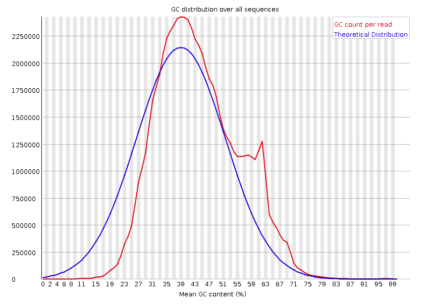

peak

This is probably caused by the highly repeated reads:

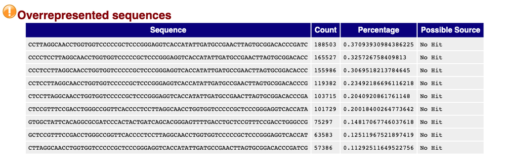

I tried to use BLAT in UCSC genome browser to see the locations of the first five reads and got:

```
r1       75     1    75    75   100.0%  chr9                  -     9442160   9442234     75
r1       75     1    75    75   100.0%  chr3                  -    15738615  15738689     75
r1       75     1    75    75   100.0%  chr14                 -    49586680  49586754     75
r1       75     1    75    75   100.0%  chr14                 +    49862675  49862749     75
=========
r2       75     1    75    75   100.0%  chr9                  -     9442165   9442239     75
r2       75     1    75    75   100.0%  chr3                  -    15738620  15738694     75
r2       75     1    75    75   100.0%  chr14                 -    49586685  49586759     75
r2       75     1    75    75   100.0%  chr14                 +    49862670  49862744     75
=========
r3       75     1    75    75   100.0%  chr9                  -     9442164   9442238     75
r3       75     1    75    75   100.0%  chr3                  -    15738619  15738693     75
r3       75     1    75    75   100.0%  chr14                 -    49586684  49586758     75
r3       75     1    75    75   100.0%  chr14                 +    49862671  49862745     75

========
r4       75     1    75    75   100.0%  chr9                  -     9442191   9442265     75
r4       75     1    75    75   100.0%  chr14                 -    49586711  49586785     75
r4       75     1    75    75   100.0%  chr14                 +    49853709  49853783     75
r4       75     1    75    75   100.0%  chr14                 +    49862644  49862718     75
========
r5       75     1    75    75   100.0%  chr9                  -     9442163   9442237     75
r5       75     1    75    75   100.0%  chr3                  -    15738618  15738692     75
r5       75     1    75    75   100.0%  chr14                 -    49586683  49586757     75
r5       75     1    75    75   100.0%  chr14                 +    49862672  49862746     75
```

Looks like they are all mapped to similar regions in chr9,3,14, which are probalbly low-complexity sequences. Also, the GC% of these repeated reads are:

```python
# in python
>>> def GC(str):
...   return (str.count('G') + str.count('C')) / len(str)
...
>>> GC('CCTTAGGCAACCTGGTGGTCCCCCGCTCCCGGGAGGTCACCATATTGATGCCGAACTTAGTGCGGACACCCGATC')
0.6133333333333333
>>> GC('CCCCTCCTTAGGCAACCTGGTGGTCCCCCGCTCCCGGGAGGTCACCATATTGATGCCGAACTTAGTGCGGACACC')
0.6266666666666667
>>> GC('CCCTCCTTAGGCAACCTGGTGGTCCCCCGCTCCCGGGAGGTCACCATATTGATGCCGAACTTAGTGCGGACACCC')
0.6266666666666667
>>> GC('CTCCGTTTCCGACCTGGGCCGGTTCACCCCTCCTTAGGCAACCTGGTGGTCCCCCGCTCCCGGGAGGTCACCATA')
0.6666666666666666
>>> GC('CCTCCTTAGGCAACCTGGTGGTCCCCCGCTCCCGGGAGGTCACCATATTGATGCCGAACTTAGTGCGGACACCCG')
0.6266666666666667
```

Quite matched with the value of the peak… I think it’s OK to not to remove them in downstream analyses.

### Aligning using HISAT2

I’d like to try another splice-aware aligner HISAT2. Also, Salmon/Kallisto are pretty good choices.

#### 1. Download files

```bash
cd /athena/angsd/scratch/zhp4001/refGenome
# reference genome
wget ftp://ftp.ensembl.org/pub/release-84/fasta/homo_sapiens/dna/Homo_sapiens.GRCh38.dna.primary_assembly.fa.gz
gunzip Homo_sapiens.GRCh38.dna.primary_assembly.fa.gz
mv Homo_sapiens.GRCh38.dna.primary_assembly.fa genome.fa

# Download GTF and make exon, splicesite file
wget ftp://ftp.ensembl.org/pub/release-84/gtf/homo_sapiens/Homo_sapiens.GRCh38.84.gtf.gz
gunzip Homo_sapiens.GRCh38.84.gtf.gz
mv Homo_sapiens.GRCh38.84.gtf genome.gtf
~/tools/hisat2-2.2.1/hisat2_extract_splice_sites.py genome.gtf > genome.ss
~/tools/hisat2-2.2.1/hisat2_extract_exons.py genome.gtf > genome.exon

# Download SNP
wget http://hgdownload.cse.ucsc.edu/goldenPath/hg38/database/snp144Common.txt.gz
gunzip snp144Common.txt.gz
# Convert chromosome names of UCSC Database to Ensembl Annotation
awk 'BEGIN{OFS="\t"} {if($2 ~ /^chr/) {$2 = substr($2, 4)}; if($2 == "M") {$2 = "MT"} print}' snp144Common.txt > snp144Common.txt.ensembl

# make SNPs and haplotype file
~/tools/hisat2-2.2.1/hisat2_extract_snps_haplotypes_UCSC.py genome.fa snp144Common.txt.ensembl genome

# this HGFM index takes too long, maybe show next time
<!-- ~/tools/hisat2-2.2.1/hisat2-build -p 16 --snp genome.snp --haplotype genome.haplotype --exon genome.exon --ss genome.ss genome.fa genome_snp_tran -->

# Build HFM index
hisat2-build -p 16 genome.fa genome
```

#### 2. Align reads

```bash
cd /athena/angsd/scratch/zhp4001/data
mkdir alignments

for s in $(ls *.fastq.gz| sed 's/_.*.gz//g' | sort -u); do
echo Aligning $s...
hisat2 -q -x ../refGenome/genomeIdx/genome -1 ${s}_1.fastq.gz -2 ${s}_2.fastq.gz -S alignments/$s.sam
# convert sam to bam
samtools view -bS alignments/$s.sam | samtools sort > alignments/$s.sorted.bam
rm alignments/$s.sam
done
```

Paramters:

- `-q`: inputing fastq files
- `-x`: the basename of the index for the reference genome, it’s ‘genome’ here
- `-1`: paired-end seq file 1
- `-2`: paired-end seq file 2
- `-S`: file to write SAM alignments to, maybe S for ‘SAM’

```
Aligning SRR12953537...
50817747 reads; of these:
  50817747 (100.00%) were paired; of these:
    6182910 (12.17%) aligned concordantly 0 times
    42503692 (83.64%) aligned concordantly exactly 1 time
    2131145 (4.19%) aligned concordantly >1 times
    ----
    6182910 pairs aligned concordantly 0 times; of these:
      639055 (10.34%) aligned discordantly 1 time
    ----
    5543855 pairs aligned 0 times concordantly or discordantly; of these:
      11087710 mates make up the pairs; of these:
        5863044 (52.88%) aligned 0 times
        4518721 (40.75%) aligned exactly 1 time
        705945 (6.37%) aligned >1 times
94.23% overall alignment rate
```

I think the 94.23% alignment rate is good to go.

#### 3. BAMQC

```bash
cd alignments
/softlib/apps/EL7/BamQC/bin/bamqc -t 5 SRR12953537.sorted.bam
```

The report looks good, but has a red cross in the `Insert Length Distribution` session. Insert length means the size of the insertion between two read adapters.

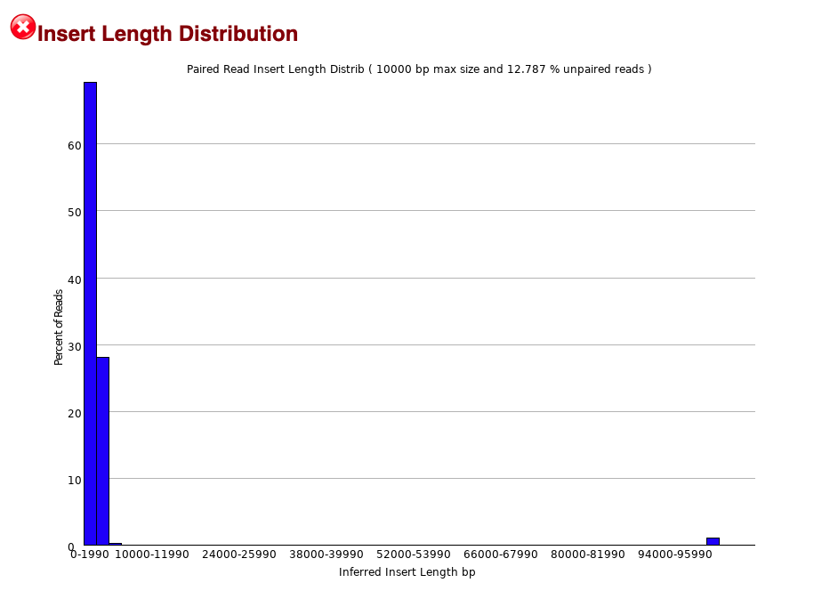

insertLen

Also, seems like HISAT2 can detect both SNPs and splicings:

- `Percent sequences spliced`: 11.610
- `Percent SNPs`: 0.416
- `Percent indels`: 0.010 (Ins: 0.005; Del: 0.005)

Overall, HISAT2 is fast for building index (the basic one), but slow for aligning that takes about 2 hours for one sample.